Blog 1: Discussing the Best Measures of Model Success Highlight: Receiver Operating Characteristic Curve (ROC) Shane Hylton 2022-12-04

# ROC Curves

An **ROC curve** (Receiver Operating Characteristic) is a curve that shows the ability of a classification model to adequately predict outcome variables. On the y-axis, we see the true positive rate, and on the x-axis, we see the false positive rate. The area under the curve can be described as the probability that the classification model will be able to properly classify the inputs.

Throughout the semester, we have heavily used the ROC curve, and I have grown very fond of using it as a measure of the performance of models that I create. It is often very difficult to find one good representation of a model’s performance, but the ROC curve is a good candidate for a single measure of model quality.

As an example, below is an ROC curve that was produced for one of our modelling assignments. Sensitivity vs. Specificity is another way to label the true positive rate vs. false positive rate. While the ROC curve does not completely represent the quality of a model, it does do a fantastic job at providing a general understanding of the ability of the model to properly predict the class of the dependent variable. A concave shape is indicative of a better model than a model with a convex shape (curve opens upwards).

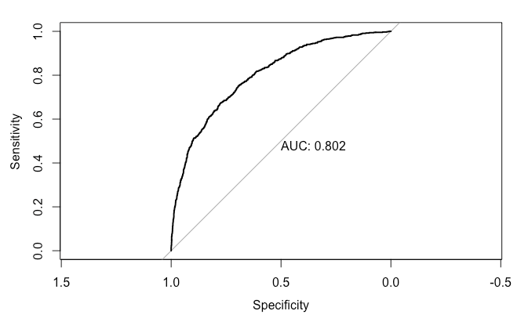

Sample ROC Curve

The ROC Curve will always have a maximum value of 1 and a minimum value of 0 in the x and y axes. Also, note that the x-axis shows Specificity and not 1 - Specificity. The pROC package will display the x-axis as decreasing from 1 to 0, instead of increasing from 0 to 1. The classic style will show 1 - Specificity on the x-axis, so it is important to note that the pROC package shows Specificity on the x-axis, and that the values decrease.

Overall, the ROC curve is one of the best single representations of a model’s quality, but it is important that we also consider measurements like $R^2$, AIC, and Root Mean Squared Error. A great reason to use the ROC Curve as the primary measure of a model’s success is that it takes into account both Sensitivity and Specificity. Other important measures that are easily computed and are closely related with the ROC curve include precision, recall, and F1-Score. All of these quantities can be derived from the Confusion Matrix.

# Confusion Matrix and Important Quantities

The Confusion Matrix is the foundation for the ROC Curve. It provides a table of observed and predicted classes, and it includes true positives, true negatives, false positives, and false negatives all in the same table. The caret package has a function called confusionMatrix() that will produce a confusion matrix, along with many other important statistics. These four prediction outcomes are the building blocks for the ROC curve and the other important quantities listed below.

$TP = True \space Positives$ $TN = True \space Negatives$ $FP = False \space Positives$ $FN = False \space Negatives$

${Accuracy} = \frac{TP + TN}{TP + FP + TN + FN}$

${Classification \space Error \space Rate} = \frac{FP + FN}{TP + FP + TN + FN}$

${Precision} = \frac{TP}{TP + FP}$

${Sensitivity} = \frac{TP}{TP + FN}$

${Specificity} = \frac{TN}{TN + FP}$

${F1 \space Score} = \frac{2 \times Precision \times Sensitivity}{Precision + Sensitivity}$